# MNist Hello World Example Part 2

We will step through the Data Process. Steps 1-4 are explained in [Part 1](https://robsap.github.io/projects/MNIST_keras2.html) of this project located [here](https://robsap.github.io/projects/MNIST_keras2.html). This is a continuation of part 4. We do briefly describe a difference in the Data Processing step.

Data Procoss Steps

1. Goal or Hypothesis
2. Data Retrieval
3. Data Processing
4. Data Exploration
5. Model Data
6. Present Results

# Data Processing

The difference here is how we split the data and reshape it. This way we can use the convolutions in Keras. We are using Tensorflow for backend, thus need tensorflows shape.

```python
#Part 2,3 recap

from keras.datasets import mnist #Loads the Data Set
from keras.utils import to_categorical

#load the data
(x_train, y_train), (x_test, y_test) = mnist.load_data()

#Change values from uint8 (0 to 255) to float32 (0 to 1)
x_train = x_train.astype('float32')/255
x_test = x_test.astype('float32')/255

#Number of images, height, width, color dimension
x_train = x_train.reshape(x_train.shape[0], 28, 28, 1)
x_test = x_test.reshape(x_test.shape[0], 28, 28, 1)

#Change labels to categorical format
y_test = to_categorical(y_test)
y_train = to_categorical(y_train)
```

# Model Data Part

In this example, we use a convolutional neural network to process our images. In this we learn what the images attributes look like. We have 2 models, a basic one, and a more complex one. Due to the limitaions of the computer this code is running on, we keep the backend using the CPU and not the GPU.

```python
from keras import models #Loads models
from keras import layers #Loads Layers

def my_model_01():
    #This is a basic CNN.
    # Train - epoch: 3,batch: 64 - loss: 0.0664 - acc: 0.9808 - val_loss: 0.0732 - val_acc: 0.9806
    # Test - epoch 3, batch - 64 - Loss 0.06305718464348466 Accuracy 0.979
    model = models.Sequential()
    model.add(layers.Conv2D(32,(3,3),activation='relu', input_shape=(28,28,1)))
    model.add(layers.Flatten())
    model.add(layers.Dense(10,activation='softmax'))
    model.compile(optimizer="rmsprop", loss="categorical_crossentropy", metrics=["accuracy"])
    return model
```

```python
def my_model_02():
    #This is a basic CNN.
    # Train - epocn:3, batch:64 - loss: 0.0695 - acc: 0.9803 - val_loss: 0.0763 - val_acc: 0.9782
    # Test - epoch 3, batch - 64 - Loss 0.06257567940205336 Accuracy 0.9807
    model = models.Sequential()
    model.add(layers.Conv2D(32,(3,3),activation='relu', input_shape=(28,28,1)))
    model.add(layers.MaxPooling2D((2,2)))
    model.add(layers.Dropout(0.5))
    model.add(layers.Conv2D(64,(3,3),activation='relu'))
    model.add(layers.MaxPooling2D((2,2)))
    model.add(layers.Dropout(0.5))
    model.add(layers.Conv2D(64,(3,3),activation='relu'))

    model.add(layers.Flatten())
    model.add(layers.Dense(64,activation='relu'))
    model.add(layers.Dense(10,activation='softmax'))
    model.compile(optimizer="rmsprop", loss="categorical_crossentropy", metrics=["accuracy"])
    return model
```

```python
import numpy as np
#Randomly pick 10 epochs and batch_size 64
epochs = 20
batch_size = 64
model = my_model_01()
#model = my_model_02()
history = model.fit(np.array(x_train), np.array(y_train), epochs=epochs, batch_size=batch_size, validation_split=0.15)
```

```
Train on 51000 samples, validate on 9000 samples
```

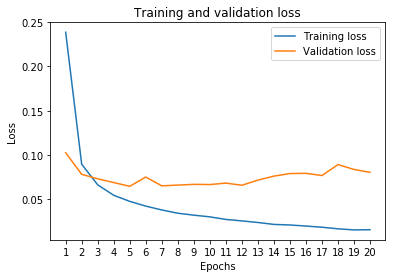

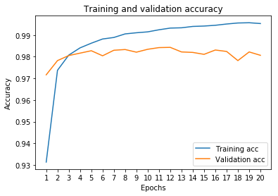

```python
import matplotlib.pyplot as plt

#Now lets evaluate the results we seen
history_dict = history.history

loss_values = history_dict['loss']
loss_values = np.array(loss_values)


val_loss_values = history_dict['val_loss']
val_loss_values = np.array(val_loss_values)

epochs = range(1, len(loss_values) + 1)
plt.xticks(epochs)

plt.plot(epochs, loss_values, label='Training loss')
plt.plot(epochs, val_loss_values, label='Validation loss')
plt.title('Training and validation loss')
plt.xlabel('Epochs')
plt.ylabel('Loss')
plt.legend()
plt.show()

plt.clf()
plt.xticks(epochs)
acc_values = history_dict['acc']
val_acc_values = history_dict['val_acc']
plt.plot(epochs, acc_values, label='Training acc')
plt.plot(epochs, val_acc_values, label='Validation acc')
plt.title('Training and validation accuracy')
plt.xlabel('Epochs')
plt.ylabel('Accuracy')
plt.legend()
plt.show()
```

```python
#Fit/Train the model
model = my_model_01()
#model = my_model_02()
model.fit(x_train, y_train, epochs = 3, batch_size=64)

#See how accurate the training model is against a test set
loss, accuracy = model.evaluate(x_test,y_test)
print("Loss " + str(loss))
print("Accuracy " + str(accuracy))
```

```
Loss 0.06305718464348466
Accuracy 0.979
```

# Results

The basic CNN can do 97.9% accuracy. The more advance CNN can do 98.07%. With more tuning, we could likely get higher without over fitting. Adding more layers and having a more complex model could also increase our accuracy. The problem with a larger and more complex model is the amount of time it takes to run. This is where a GPU would come in handy for speeding up the process. But with 98% accuracy, we can call this solved.